# package:

# PCA with penguins and recipes

[ここ](https://allisonhorst.github.io/palmerpenguins/articles/pca.html)を参考に PCAについてやるという話.

```r
library(palmerpenguins)
library(corrr)
library(GGally)
```

```r
library(recipes)
library(tidytext)
library(dplyr)
library(tidyr)
library(ggplot2)
theme_set(theme_minimal())
```

## correlation matrix

まずは相関係数行列を作成する. 相関係数行列を見ると、filpper_length_mm、body_mass_gの相関が強いことがわかる.

```r
penguins_corr <-
  penguins %>%
  dplyr::select(body_mass_g, ends_with("_mm")) %>%
  correlate() %>%
  rearrange()
```

```
##
## Correlation method: 'pearson'
## Missing treated using: 'pairwise.complete.obs'
```

```r
penguins_corr
```

| rowname | flipper_length_mm | body_mass_g | bill_length_mm | bill_depth_mm |
| --- | --- | --- | --- | --- |
| flipper_length_mm | NA | 0.8712018 | 0.6561813 | -0.5838512 |
| body_mass_g | 0.8712018 | NA | 0.5951098 | -0.4719156 |
| bill_length_mm | 0.6561813 | 0.5951098 | NA | -0.2350529 |
| bill_depth_mm | -0.5838512 | -0.4719156 | -0.2350529 | NA |

## pairwise plot matrix

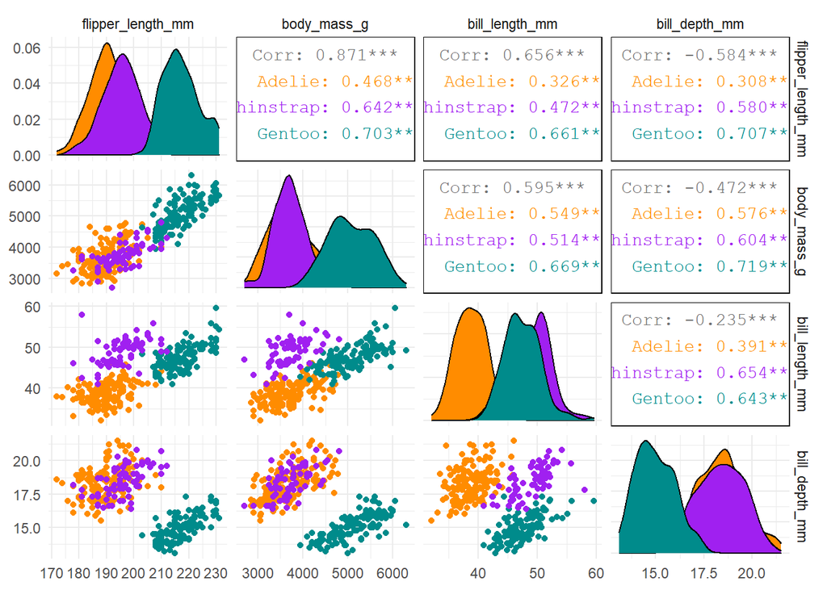

```r
penguins %>%
  select(species, body_mass_g, ends_with("_mm")) %>%
  ggpairs(
    aes(color = species),
    columns = c("flipper_length_mm", "body_mass_g", "bill_length_mm", "bill_depth_mm")
  ) +
  scale_color_manual(values = c("darkorange", "purple", "cyan4")) +
  scale_fill_manual(values = c("darkorange", "purple", "cyan4"))
```

## PCA

`recipes`パッケージを使う. PCAを使う前処理として次が必要である.

- remove any NA values
- center all predictors and scale all predictors

```r
penguin_recipe <-
  recipe( ~ ., data = penguins) %>%
  update_role(species, island, sex, year, new_role = "id") %>%
  step_naomit(all_predictors()) %>%
  step_normalize(all_predictors()) %>%
  step_pca(all_predictors(), id = "pca") %>%
  prep()
```

```r
penguin_pca <-
  penguin_recipe %>%
  tidy(id = "pca")

penguin_pca
```

| terms | value | component | id |
| --- | --- | --- | --- |
| bill_length_mm | 0.455250329 | PC1 | pca |
| bill_depth_mm | -0.400334681 | PC1 | pca |
| flipper_length_mm | 0.576013324 | PC1 | pca |
| body_mass_g | 0.548350192 | PC1 | pca |
| bill_length_mm | -0.597031143 | PC2 | pca |
| bill_depth_mm | -0.797766572 | PC2 | pca |
| flipper_length_mm | -0.002282201 | PC2 | pca |
| body_mass_g | -0.084362920 | PC2 | pca |
| bill_length_mm | -0.644301153 | PC3 | pca |
| bill_depth_mm | 0.418427239 | PC3 | pca |

[output cut: 6 more lines]

```r
penguins %>%
  dplyr::select(body_mass_g, ends_with("_mm")) %>%
  tidyr::drop_na() %>%
  scale() %>%
  prcomp() %>%
  .$rotation
```

```
##                          PC1         PC2        PC3        PC4
## body_mass_g        0.5483502 0.084362920 -0.5966001 -0.5798821
## bill_length_mm     0.4552503 0.597031143  0.6443012 -0.1455231
## bill_depth_mm     -0.4003347 0.797766572 -0.4184272  0.1679860
## flipper_length_mm  0.5760133 0.002282201 -0.2320840  0.7837987
```

PCAの寄与度を可視化する.

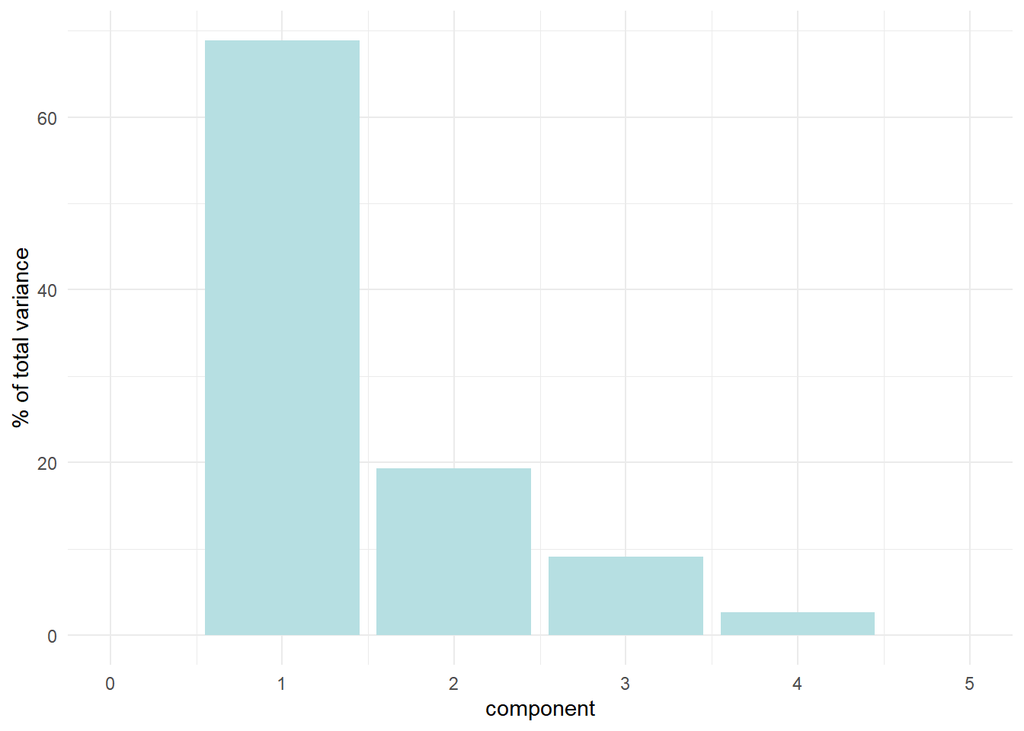

```r
penguin_recipe %>%
  tidy(id = "pca", type = "variance") %>%
  dplyr::filter(terms == "percent variance") %>%
  ggplot(aes(x = component, y = value)) +
  geom_col(fill = "#b6dfe2") +
  xlim(c(0, 5)) +
  ylab("% of total variance")
```

## Plot PCA loadings

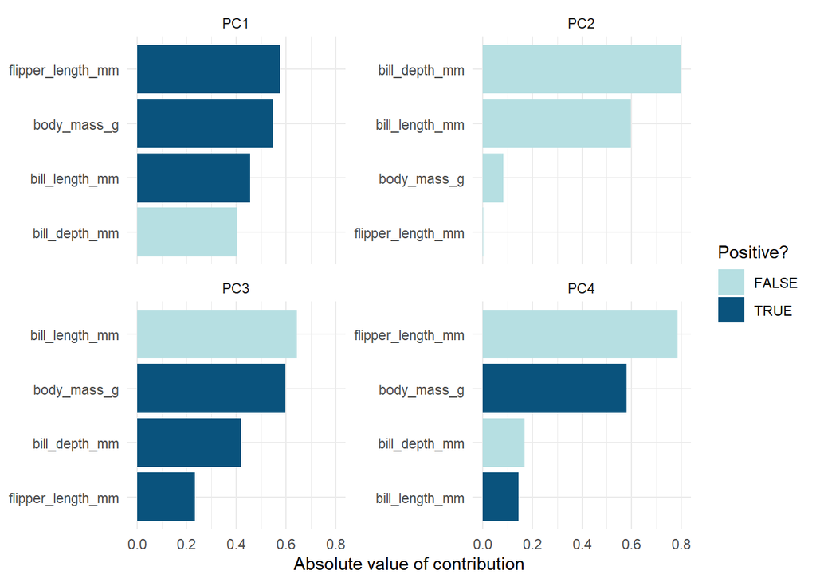

```r
library(ggplot2)
penguin_pca %>%
  mutate(terms = tidytext::reorder_within(terms,
                                          abs(value),
                                          component)) %>%
  ggplot(aes(abs(value), terms, fill = value > 0)) +
  geom_col() +
  facet_wrap(~component, scales = "free_y") +
  tidytext::scale_y_reordered() +
  scale_fill_manual(values = c("#b6dfe2", "#0A537D")) +
  labs(
    x = "Absolute value of contribution",
    y = NULL, fill = "Positive?"
  )
```

## Plot PCA loadings + scores

```r
pca_wider <-
  penguin_pca %>%
  pivot_wider(names_from = component, id_cols = terms)
```

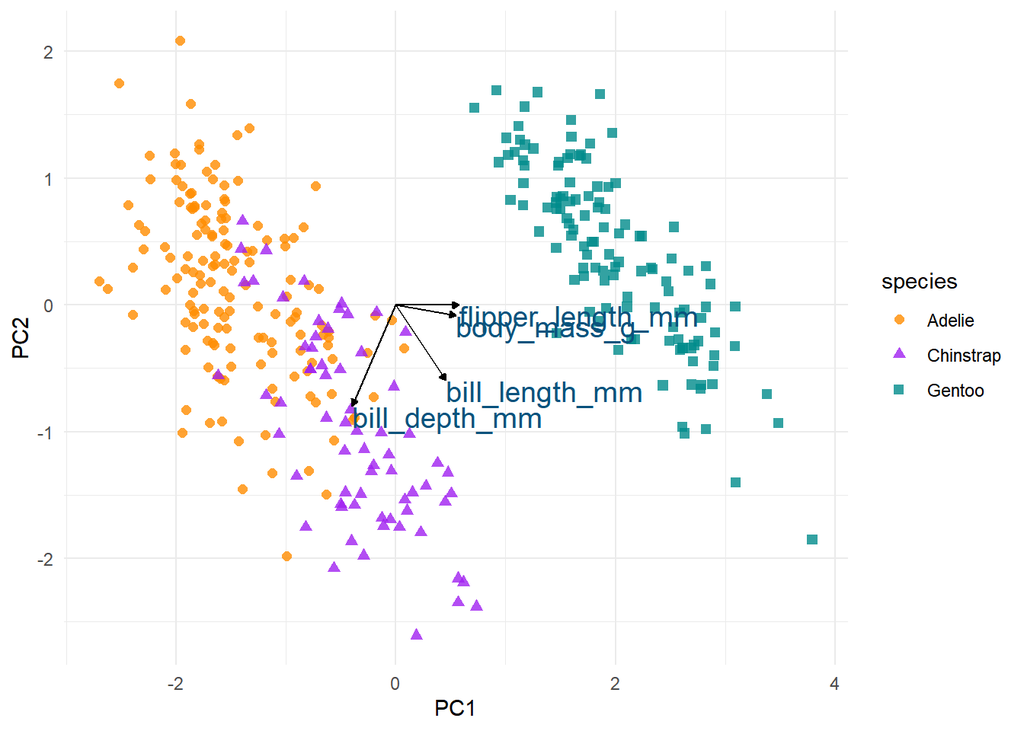

```r
# define arrow style
arrow_style <-
  arrow(
    length = unit(.05, "inches"),
    type = "closed"
  )

pca_plot <-
  juice(penguin_recipe) %>%
  ggplot(aes(PC1, PC2)) +
  geom_point(aes(color = species, shape = species),
             alpha = .8, size = 2) +
  scale_colour_manual(values = c("darkorange", "purple", "cyan4"))

pca_plot +
  geom_segment(data = pca_wider,
               aes(xend = PC1, yend = PC2),
               x = 0, y = 0, arrow = arrow_style) +
  geom_text(data = pca_wider,
            aes(x = PC1, y = PC2, label = terms),
            hjust = 0,
            vjust = 1,
            size  = 5,
            color = "#0A537D")
```

なんというか、このグラフのわかりやすさには驚嘆せざるを得ない。 `filpper_length_mm`と`body_mass_g`が同様にPC1に効いていることがわかる。 そしてPC1により、Gentoo種とその他の種が分離できそうなことがわかる.

```r
penguins %>%
  group_by(species) %>%
  select(flipper_length_mm, body_mass_g) %>%
  summarise_all(mean, na.rm = TRUE)
```

| species | flipper_length_mm | body_mass_g |
| --- | --- | --- |
| Adelie | 189.9536 | 3700.662 |
| Chinstrap | 195.8235 | 3733.088 |
| Gentoo | 217.1870 | 5076.016 |

もう少し詳しく見てみる.

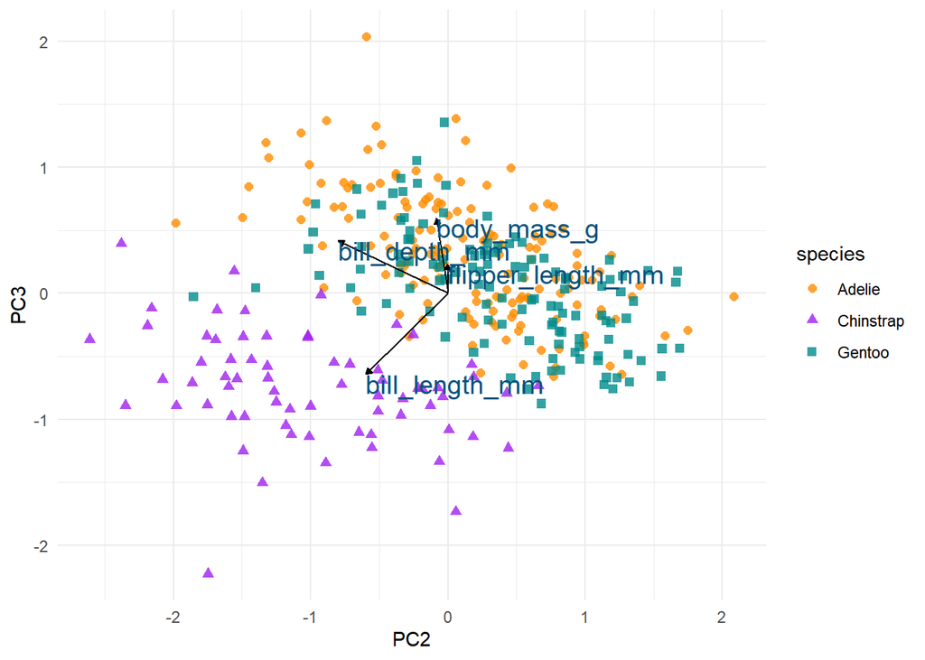

```r
pca_plot %+%
  aes(PC2, PC3) +
  geom_segment(data = pca_wider,
               aes(xend = PC2, yend = PC3),
               x = 0,
               y = 0,
               arrow = arrow_style) +
  geom_text(data = pca_wider,
            aes(x = PC2, y = PC3, label = terms),
            hjust = 0,
            vjust = 1,
            size = 5,
            color = '#0A537D')
```